# 2.3.65

## 2.3.65

A simple quantitative data set has been provided. Use limit grouping with a first class of 0-4and a class width of 5 to complete parts (a) through (d) for this data set.

**(a) Determine a frequency distribution.**

First, we need to import the data from Excel. (For simplicity, this imports mannual by hand, we can get the same result by importing dataset from Excel)

```r
data <- c(21, 6, 2, 4, 2, 23, 17, 9, 24, 12, 3, 22, 26, 28, 9, 18, 4, 27, 0, 26)
data
```

```
##  [1] 21  6  2  4  2 23 17  9 24 12  3 22 26 28  9 18  4 27  0 26
```

We can get the frequency by using table() command

```r
table(data)
```

```
## data
##  0  2  3  4  6  9 12 17 18 21 22 23 24 26 27 28
##  1  2  1  2  1  2  1  1  1  1  1  1  1  2  1  1
```

To display bin frenquency table use as.data.frame() command

```r
k = as.data.frame(table(cut(data, breaks=seq(0,30, by=5))))
k
```

```
##      Var1 Freq
## 1   (0,5]    5
## 2  (5,10]    3
## 3 (10,15]    1
## 4 (15,20]    2
## 5 (20,25]    4
## 6 (25,30]    4
```

Since R does not count the value 0, we could double check the value in range 0-4 and readjust the value

```r
f = k$Freq
f
```

```
## [1] 5 3 1 2 4 4
```

```r
f[1] = 6
f
```

```
## [1] 6 3 1 2 4 4
```

**(b) Obtain a relative-frequency distribution.**

```r
f/length(data)
```

```
## [1] 0.30 0.15 0.05 0.10 0.20 0.20
```

To display the result appropriate to 5 decimal places use print() command

In this case, we have nice results so it does not show the difference.

```r
print(f/length(data), digits = 5)
```

```
## [1] 0.30 0.15 0.05 0.10 0.20 0.20
```

**(c) Construct a frequency histogram based on your result from part (a). Choose the correct histogram below.**

Display bar chart using barplot() command

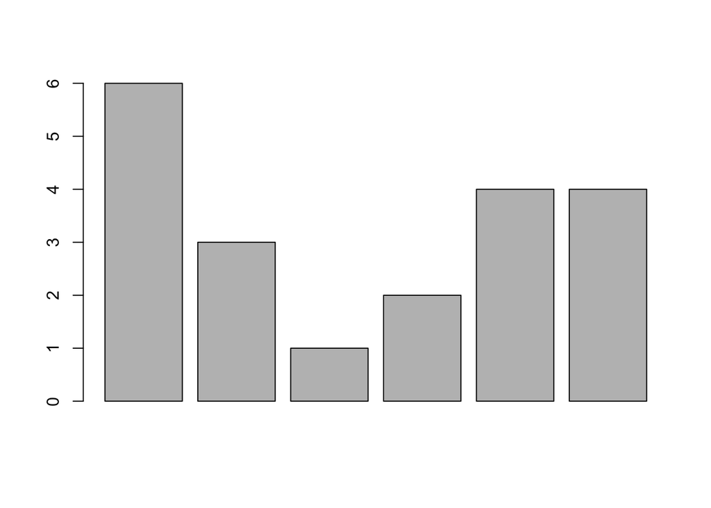

```r
barplot(f)
```

**(d) Construct a relative-frequency histogram based on your result from part (b). Choose the correct histogram below.**

The relative-frequency histogram should have the same behavior with the one in part (c). We can get histogram plot by using barplot() command

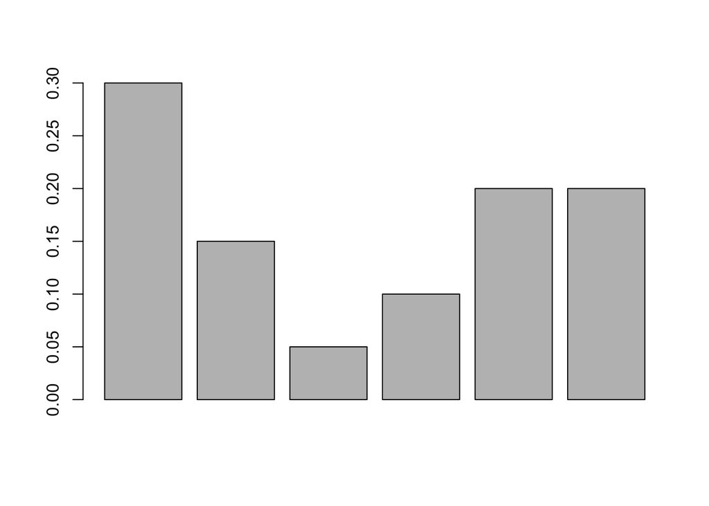

```r
barplot(f/length(data))
```

**Hope that helps!**